# DS220 Final Project by Aarush Bansal

### Analyzing the GDP data of the USA for the past 43 years (till 1980)

Understanding our basic economic standing in the form of gross domestic product is important as it helps us understand how the USA's economy is not only measured, but what weighs into it and by further analyzing the makeup of GDP, we can start to create conclusions about economic growth and increase our understanding of how various monetary vehicles (such as the housing market or the stock market) effect the country as a whole. This is the role of Macro-economists, and by utilizing the data science tools explored in class, we can make their life simpler and display the data in a convenient way that visualizes the necessary data for them to make judgements about the health of the United States economy.

I started the project by going to: https://bea.gov and downloading interactive data 1.1.5 from the Gross Domestic Product tab in tools. From there I edited the data I want to download by changing the range of data from 2020-2023 quarterly to 1980 - 2023 annually. Then I downloaded a csv file that I then had to edit so that the formatting is more pandas friendly by deleting extra lines that were unnecessary. I then started to look at the data through pandas.

Basic import of the important libraries being utilized in this project.

```python
# Import libraries
import pandas as pd
import matplotlib.pyplot as plt
import numpy as np
```

I download the csv file and start to open it up and make sure all the line counts are equal so that I can properly perform the analysis. I also made sure to convert the first column and row into indexes and headers respectively.

```python
# Defining data for the dataframe
pd.set_option('display.max_rows', 28)
rawData = pd.read_csv("DS220FinalData.csv")
rawData.info()
```

```
<class 'pandas.core.frame.DataFrame'>
RangeIndex: 26 entries, 0 to 25
Data columns (total 45 columns):
 #   Column    Non-Null Count  Dtype
---  ------    --------------  -----
 0   Category  26 non-null     object
 1   1980      26 non-null     float64
 2   1981      26 non-null     float64
 3   1982      26 non-null     float64
 4   1983      26 non-null     float64
 5   1984      26 non-null     float64
 6   1985      26 non-null     float64
 7   1986      26 non-null     float64
 8   1987      26 non-null     float64
 9   1988      26 non-null     float64
```

[output cut: 37 more lines]

Here is the outline of the data and what it looks like. It breaks down the GDP of the USA per year (column) in subsequent parts such as personal consumption, goods, services, investments, etc. Using this data we will look at how important these factors are in total GDP and analyze where a good portion of our GDP is actually created from.

```python
rawData = rawData.set_index("Category")
rawData.head(28)
```

| Category | 1980 | 1981 | 1982 | 1983 | 1984 | 1985 | 1986 | 1987 | 1988 | 1989 | ... | 2014 | 2015 | 2016 | 2017 | 2018 | 2019 | 2020 | 2021 | 2022 | 2023 |
| --- | --- | --- | --- | --- | --- | --- | --- | --- | --- | --- | --- | --- | --- | --- | --- | --- | --- | --- | --- | --- | --- |
| Gross domestic product | 2857.3 | 3207.0 | 3343.8 | 3634.0 | 4037.6 | 4339.0 | 4579.6 | 4855.2 | 5236.4 | 5641.6 | ... | 17608.1 | 18295.0 | 18804.9 | 19612.1 | 20656.5 | 21521.4 | 21323.0 | 23594.0 | 25744.1 | 27360.9 |
| Personal consumption expenditures | 1750.7 | 1934.0 | 2071.3 | 2281.6 | 2492.3 | 2712.8 | 2886.3 | 3076.3 | 3330.0 | 3576.8 | ... | 11874.5 | 12297.4 | 12726.8 | 13290.6 | 13934.4 | 14417.6 | 14206.2 | 16043.0 | 17511.7 | 18570.6 |
| Goods | 799.8 | 869.4 | 899.3 | 973.8 | 1063.7 | 1137.6 | 1195.6 | 1256.3 | 1337.3 | 1423.8 | ... | 3886.6 | 3955.1 | 4033.0 | 4212.2 | 4414.2 | 4529.2 | 4713.1 | 5506.6 | 5997.0 | 6191.5 |
| Durable goods | 226.4 | 243.9 | 253.0 | 295.0 | 342.2 | 380.4 | 421.4 | 442.0 | 475.1 | 494.3 | ... | 1247.3 | 1315.8 | 1356.5 | 1415.9 | 1488.8 | 1522.7 | 1628.9 | 2006.4 | 2128.9 | 2198.8 |
| Nondurable goods | 573.4 | 625.4 | 646.3 | 678.8 | 721.5 | 757.2 | 774.2 | 814.3 | 862.3 | 929.5 | ... | 2639.3 | 2639.3 | 2676.5 | 2796.3 | 2925.4 | 3006.5 | 3084.2 | 3500.2 | 3868.1 | 3992.7 |
| Services | 950.9 | 1064.6 | 1172.0 | 1307.8 | 1428.6 | 1575.2 | 1690.7 | 1820.0 | 1992.7 | 2153.0 | ... | 7987.9 | 8342.3 | 8693.8 | 9078.4 | 9520.2 | 9888.5 | 9493.1 | 10536.3 | 11514.7 | 12379.2 |
| Gross private domestic investment | 530.1 | 631.2 | 581.0 | 637.5 | 820.1 | 829.7 | 849.1 | 892.2 | 937.0 | 999.7 | ... | 3074.0 | 3288.5 | 3278.3 | 3467.7 | 3724.8 | 3892.4 | 3748.4 | 4216.3 | 4756.6 | 4843.9 |
| Fixed investment | 536.4 | 601.4 | 595.9 | 643.3 | 754.7 | 807.8 | 842.6 | 865.0 | 918.5 | 972.0 | ... | 2989.2 | 3148.4 | 3239.2 | 3435.0 | 3668.4 | 3820.2 | 3785.9 | 4204.6 | 4599.3 | 4790.3 |
| Nonresidential | 406.9 | 472.9 | 485.1 | 482.2 | 564.3 | 607.8 | 607.8 | 615.2 | 662.3 | 716.0 | ... | 2425.2 | 2507.5 | 2529.0 | 2661.1 | 2856.5 | 2993.1 | 2869.4 | 3078.4 | 3433.0 | 3716.1 |
| Structures | 136.2 | 167.3 | 177.6 | 154.3 | 177.4 | 194.5 | 176.5 | 174.2 | 182.8 | 193.7 | ... | 574.6 | 584.5 | 566.2 | 594.9 | 636.6 | 678.7 | 623.2 | 623.9 | 700.5 | 839.8 |
| Equipment | 216.4 | 240.9 | 234.9 | 246.5 | 291.9 | 307.9 | 317.7 | 320.9 | 346.8 | 372.2 | ... | 1109.1 | 1144.1 | 1119.8 | 1160.0 | 1227.6 | 1241.5 | 1110.8 | 1188.2 | 1327.2 | 1381.4 |
| Intellectual property products | 54.4 | 64.8 | 72.7 | 81.3 | 95.0 | 105.3 | 113.5 | 120.1 | 132.7 | 150.1 | ... | 741.5 | 778.9 | 843.0 | 906.2 | 992.2 | 1072.9 | 1135.5 | 1266.3 | 1405.4 | 1495.0 |
| Residential | 129.5 | 128.5 | 110.8 | 161.1 | 190.4 | 200.1 | 234.8 | 249.8 | 256.2 | 256.0 | ... | 564.0 | 640.9 | 710.2 | 773.9 | 811.9 | 827.2 | 916.5 | 1126.2 | 1166.4 | 1074.2 |
| Change in private inventories | -6.3 | 29.8 | -14.9 | -5.8 | 65.4 | 21.8 | 6.6 | 27.1 | 18.5 | 27.7 | ... | 84.8 | 140.1 | 39.1 | 32.7 | 56.4 | 72.2 | -37.6 | 11.7 | 157.3 | 53.6 |
| Net exports of goods and services | -13.1 | -12.5 | -20.0 | -51.6 | -102.7 | -114.0 | -131.9 | -144.8 | -109.4 | -86.7 | ... | -508.9 | -524.3 | -503.3 | -543.3 | -593.1 | -578.5 | -626.4 | -858.2 | -971.1 | -798.7 |
| Exports | 280.8 | 305.2 | 283.2 | 277.0 | 302.4 | 303.2 | 321.0 | 363.9 | 444.6 | 504.3 | ... | 2378.5 | 2270.6 | 2235.6 | 2388.3 | 2538.1 | 2538.5 | 2150.1 | 2550.0 | 2995.0 | 3027.2 |
| Goods | 230.4 | 245.2 | 222.6 | 214.0 | 231.3 | 227.5 | 231.4 | 265.6 | 332.1 | 374.8 | ... | 1617.0 | 1496.7 | 1447.6 | 1546.7 | 1669.3 | 1644.8 | 1421.6 | 1746.0 | 2063.2 | 2031.3 |
| Services2 | 50.3 | 60.0 | 60.7 | 62.9 | 71.1 | 75.7 | 89.6 | 98.4 | 112.5 | 129.5 | ... | 761.6 | 773.9 | 788.0 | 841.6 | 868.8 | 893.7 | 728.5 | 804.1 | 931.8 | 996.0 |
| Imports | 293.8 | 317.8 | 303.2 | 328.6 | 405.1 | 417.2 | 452.9 | 508.7 | 554.0 | 591.0 | ... | 2887.4 | 2794.9 | 2738.8 | 2931.6 | 3131.2 | 3117.0 | 2776.5 | 3408.3 | 3966.2 | 3825.9 |
| Goods | 248.6 | 267.8 | 250.5 | 272.7 | 336.3 | 343.3 | 370.0 | 414.8 | 452.1 | 484.8 | ... | 2389.3 | 2289.6 | 2218.7 | 2369.9 | 2559.1 | 2516.7 | 2305.1 | 2842.4 | 3262.4 | 3111.8 |
| Services3 | 45.3 | 49.9 | 52.6 | 56.0 | 68.8 | 73.9 | 82.9 | 93.9 | 101.9 | 106.2 | ... | 498.1 | 505.4 | 520.1 | 561.7 | 572.1 | 600.3 | 471.4 | 565.9 | 703.8 | 714.1 |
| Government consumption expenditures and gross investment | 589.6 | 654.4 | 711.5 | 766.6 | 827.9 | 910.5 | 976.1 | 1031.5 | 1078.9 | 1151.9 | ... | 3168.6 | 3233.4 | 3303.0 | 3397.1 | 3590.4 | 3789.9 | 3994.8 | 4193.1 | 4446.8 | 4745.1 |
| Federal | 274.9 | 314.0 | 348.3 | 382.4 | 411.8 | 452.9 | 481.7 | 502.8 | 511.4 | 534.1 | ... | 1217.1 | 1222.8 | 1237.4 | 1266.1 | 1346.3 | 1422.2 | 1523.4 | 1594.3 | 1635.5 | 1771.7 |
| National defense | 183.4 | 213.4 | 245.4 | 272.1 | 298.8 | 329.5 | 352.4 | 372.4 | 382.1 | 391.2 | ... | 744.1 | 730.4 | 729.4 | 748.3 | 795.1 | 851.1 | 884.6 | 898.6 | 928.4 | 994.7 |
| Nondefense | 91.5 | 100.6 | 102.9 | 110.3 | 113.0 | 123.4 | 129.3 | 130.4 | 129.3 | 142.9 | ... | 473.0 | 492.4 | 507.9 | 517.8 | 551.2 | 571.1 | 638.8 | 695.7 | 707.1 | 777.0 |
| State and local | 314.7 | 340.4 | 363.1 | 384.2 | 416.1 | 457.6 | 494.4 | 528.7 | 567.4 | 617.8 | ... | 1951.5 | 2010.6 | 2065.7 | 2131.1 | 2244.1 | 2367.7 | 2471.3 | 2598.7 | 2811.3 | 2973.4 |

26 rows × 44 columns

Here is the Gross Domestic Product visualized by isolating the first row of the data and creating a graph that displays the growth of GDP from 1980 to 2023.

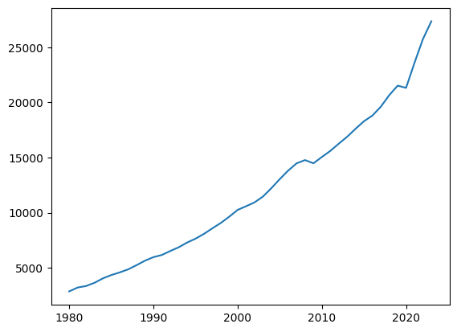

```python
row = rawData.iloc[0]
row.plot()
plt.show()
```

Here is the data shown as a bar graph to more accurately display each individual year's GDP

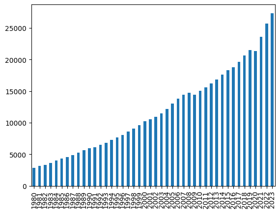

```python
row = rawData.iloc[0]
row.plot(kind ='bar')
plt.show()
```

From this data we can see a gradual upward trend of GDP with the exception of the drop recorded in 2009 after the 2008 financial and housing crises which caused a recession alongside the dip in 2020 caused by the COVID-19 pandemic.

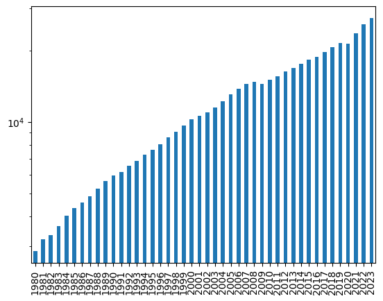

```python
row = rawData.iloc[0]
row.plot(kind ='bar', logy = True)
plt.show()
```

The new graph is with the resulting y-axis being converted to the logarithmic scale to very slightly linearize the data shown. This removes that exponential shape and makes the data slightly easier to view and work with in terms of change.

### 1) How does Personal Consumption factor into the greater gross Domestic Product?

```python
rawData.loc["PCE/GDP percentage"] = rawData.loc['Personal consumption expenditures']/rawData.loc['Gross domestic product']
rawData.loc["PCE/GDP percentage"]*= 100
print(rawData.loc["PCE/GDP percentage"])
print(rawData.loc["PCE/GDP percentage"].mean())
```

```
1980    61.271130
1981    60.305582
1982    61.944494
1983    62.784810
1984    61.727264
          ...
2019    66.991924
2020    66.623833
2021    67.996101
2022    68.022188
2023    67.872767
Name: PCE/GDP percentage, Length: 44, dtype: float64
65.7022160090293
```

Here we found what percentage of gross domestic product is made up of Personal consumption expenditures by dividing a row by another. I then multiplied by 100 to display the data in a percentage format. I also calculated the mean of 65.7%.

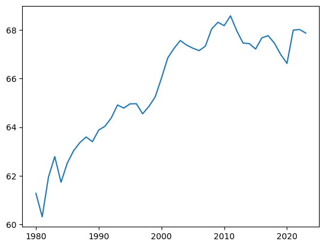

```python
row = rawData.loc['PCE/GDP percentage']
row.plot()
plt.show()
```

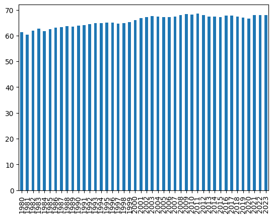

```python
row = rawData.loc['PCE/GDP percentage']
row.plot(kind = 'bar')
plt.show()
```

Here the data is displayed as a graph shows us something interesting.

It seems that roughly from the 1980 to 2023, households have become richer in comparison to the total GDP of the United States. This means that the total percentage of the gross domestic product being made from household spending has been roughly increasing, from which we can infer that means that households are spending more and by proxy, have more to spend. This metric, shown by the graphs, explains the general state of wealth of the citizens of the United States. The data of personal consumption is also made up of durable goods (houses, factories, and other long term things we buy), Non-durable goods (food, game consoles, and other creature comforts), and services (work from other humans like plumbing or electrical work).

```
1980    12.931970
1981    12.611169
1982    12.214551
1983    12.929523
1984    13.730289
          ...
2019    10.561397
2020    11.466120
2021    12.506389
2022    12.157015
2023    11.840221
Name: Durable Goods/Personal consumption expenditures, Length: 44, dtype: float64
12.311177256395304
```

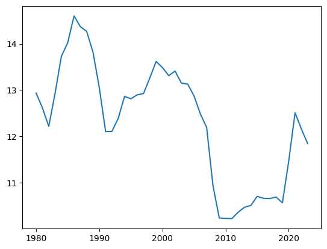

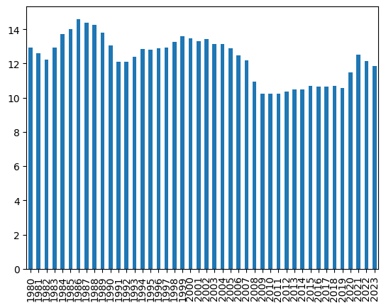

```python
rawData.loc["Durable Goods/Personal consumption expenditures"] = (rawData.loc['Durable goods']/rawData.loc['Personal consumption expenditures'])
rawData.loc["Durable Goods/Personal consumption expenditures"]*=100
print(rawData.loc["Durable Goods/Personal consumption expenditures"])
print(rawData.loc["Durable Goods/Personal consumption expenditures"].mean())

row = rawData.loc['Durable Goods/Personal consumption expenditures']
row.plot()
plt.show()

row.plot(kind = 'bar')
plt.show()
```

Here is the percentage of durable goods out of Personal Consumption. The only information this information really shows is the small amount of the gross domestic product is made up of the purchase of durable goods. Meaning not that many people are buying things like houses very commonly which would logically make sense as the average American only lives in one place and very few have the privledge of buying and owning/renting multiple properties at once.

```
1980    32.752613
1981    32.337125
1982    31.202626
1983    29.751052
1984    28.949163
          ...
2019    20.852985
2020    21.710239
2021    21.817615
2022    22.088661
2023    21.500113
Name: Nondurable Goods/Personal consumption expenditures, Length: 44, dtype: float64
24.028175452919893
```

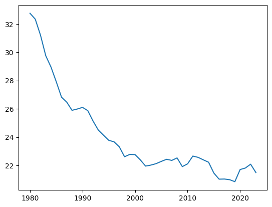

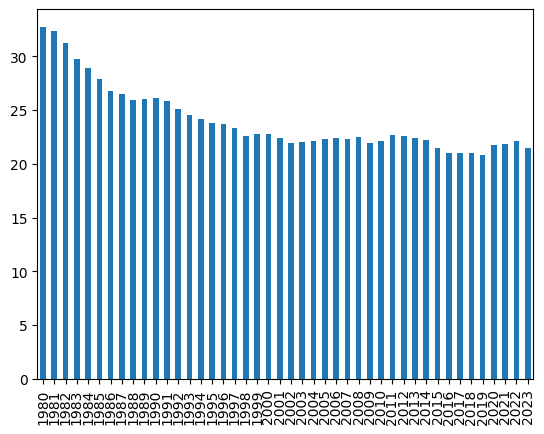

```python
rawData.loc["Nondurable Goods/Personal consumption expenditures"] = (rawData.loc['Nondurable goods']/rawData.loc['Personal consumption expenditures'])
rawData.loc["Nondurable Goods/Personal consumption expenditures"]*=100
print(rawData.loc["Nondurable Goods/Personal consumption expenditures"])
print(rawData.loc["Nondurable Goods/Personal consumption expenditures"].mean())

row = rawData.loc['Nondurable Goods/Personal consumption expenditures']
row.plot()
plt.show()

row.plot(kind = 'bar')
plt.show()
```

```
1980    54.315417
1981    55.046536
1982    56.582822
1983    57.319425
1984    57.320547
          ...
2019    68.586311
2020    66.823640
2021    65.675372
2022    65.754324
2023    66.660205
Name: Services/Personal consumption expenditures, Length: 44, dtype: float64
63.660595036484864
```

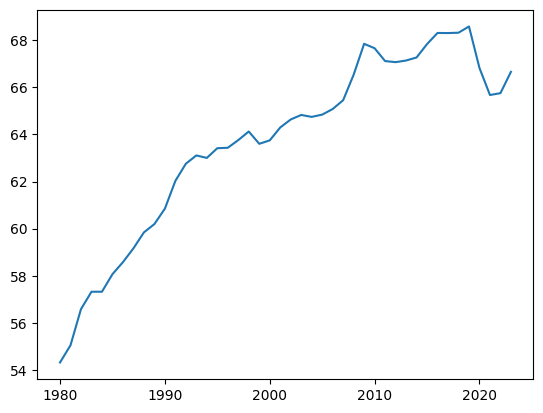

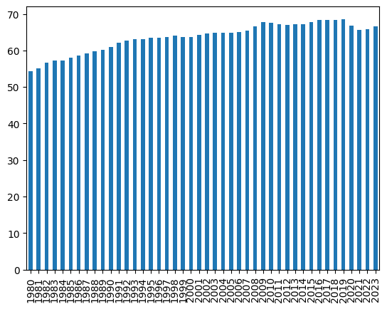

```python
rawData.loc["Services/Personal consumption expenditures"] = rawData.loc['Services']/rawData.loc['Personal consumption expenditures']
rawData.loc["Services/Personal consumption expenditures"]*=100
print(rawData.loc["Services/Personal consumption expenditures"])
print(rawData.loc["Services/Personal consumption expenditures"].mean())

row = rawData.loc['Services/Personal consumption expenditures']
row.plot()
plt.show()

row.plot(kind = 'bar')
plt.show()
```

Here is the percentage of services out of Personal Consumption. This graph, unlike both goods, shows an upward trend just like how the percentage of Personal Consumption in gross Domestic Product does. This means that unlike Nondurable and durable goods, services are becoming more and more relevant to the overall GDP of America. This could be reflective of part of the job market as many jobs in the USA are ones that provide a service of some kind to another person or company.

### 2) How does business investment factor into the greater gross Domestic Product?

```
1980    18.552480
1981    19.681946
1982    17.375441
1983    17.542653
1984    20.311571
          ...
2019    18.086184
2020    17.579140
2021    17.870221
2022    18.476466
2023    17.703731
Name: GDPI/GDP, Length: 44, dtype: float64
17.697955520715336
```

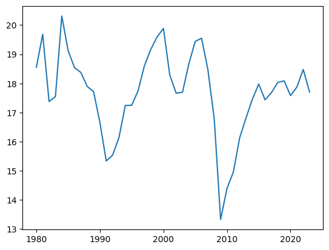

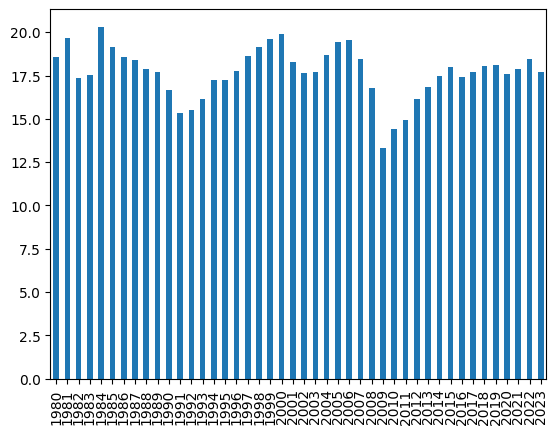

```python
rawData.loc['GDPI/GDP'] = rawData.loc['Gross private domestic investment']/rawData.loc['Gross domestic product']
rawData.loc['GDPI/GDP']*= 100
print(rawData.loc['GDPI/GDP'])
print(rawData.loc['GDPI/GDP'].mean())

row = rawData.loc['GDPI/GDP']
row.plot()
plt.show()

row.plot(kind = 'bar')
plt.show()
```

From the visible data, we can see that business investments addition to the total gross domestic product varies heavily but seems to trend very slightly downward. It seems to be super reliant on depressions/recessions and external economic factors that hit the investment a lot more. This may be due to drops in interest rate making the value of invested capital drop alongside it and can heavily change valuations of various investments

### 3) How much of a change was there throughout housing as an investment vehicle throughout the full time range?

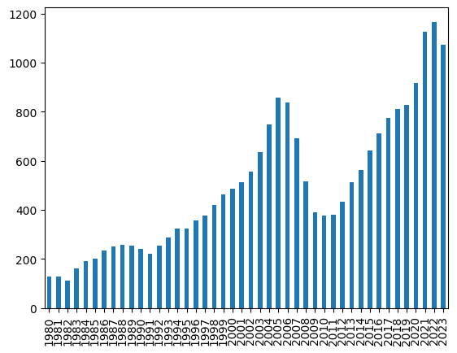

```python
row = rawData.loc['Residential']
row.plot(kind ='bar')
plt.show()
```

Looking at the bar graph displaying the residential investments (housing or rentals) we can see that housing seems to be extremely volatile but the reality was that the massive drop of 2008 was caused do to a reinvestment of defaulting mortgages which lead to a massive crash in the housing market. Other than that massive drop it seems to be that the housing market is slowly increasing over time, and does increase in value.

```
1980    4.532251
1981    4.006860
1982    3.313595
1983    4.433132
1984    4.715673
          ...
2019    3.843616
2020    4.298176
2021    4.773247
2022    4.530747
2023    3.926040
Name: Residential/GDP, Length: 44, dtype: float64
4.278565338683411
4.278565338683411
```

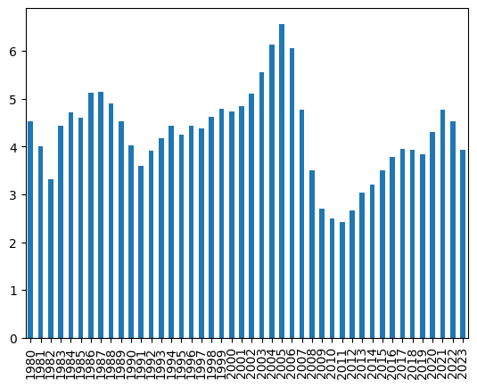

```python
rawData.loc['Residential/GDP'] = rawData.loc['Residential']/rawData.loc['Gross domestic product']
rawData.loc['Residential/GDP']*= 100
print(rawData.loc['Residential/GDP'])
print(rawData.loc['Residential/GDP'].mean())

row = rawData.loc['Residential/GDP']
print(row.mean())

row.plot(kind = 'bar')
plt.show()
```

After adjusting for GDP, we can see that housing doesn't keep up as well when compared to the overall growth of GDP as there is a lot larger drops visible describing drops in the housing market when compared to the growth of the greater economy at the time. It also shows that housing is a surprisingly large part of gdp, which is roughly 4.2 percent of total GDP and when you consider the entire value of the USA GDP, is quite a lot.

```
1980    4.532251
1981    4.006860
1982    3.313595
1983    4.433132
1984    4.715673
          ...
2019    3.843616
2020    4.298176
2021    4.773247
2022    4.530747
2023    3.926040
Name: Residential/GDP, Length: 44, dtype: float64
4.278565338683411
4.278565338683411
```

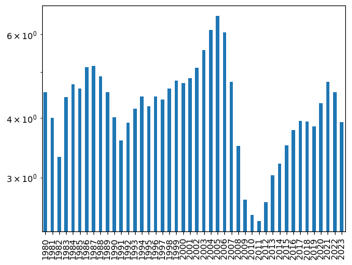

```python
rawData.loc['Residential/GDP'] = rawData.loc['Residential']/rawData.loc['Gross domestic product']
rawData.loc['Residential/GDP']*= 100
print(rawData.loc['Residential/GDP'])
print(rawData.loc['Residential/GDP'].mean())

row = rawData.loc['Residential/GDP']
print(row.mean())

row.plot(kind = 'bar', logy =  True)
plt.show()
```

By taking the log of the line we can see how drastic the changes are in comparison to the whole range pointing out the volatility of the whole range as described before when compared to GDP.

### 4) What effect do imports and exports have on gross domestic product?

```
1314.8545454545454
1683.4863636363634
```

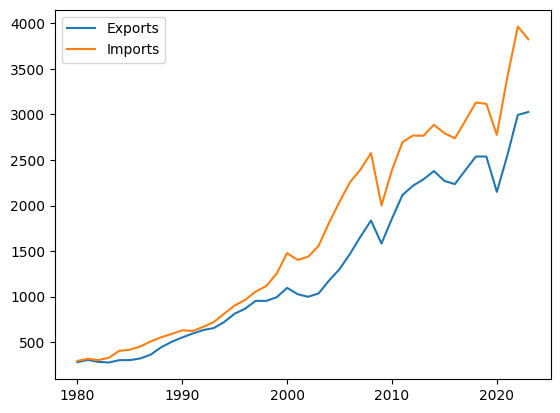

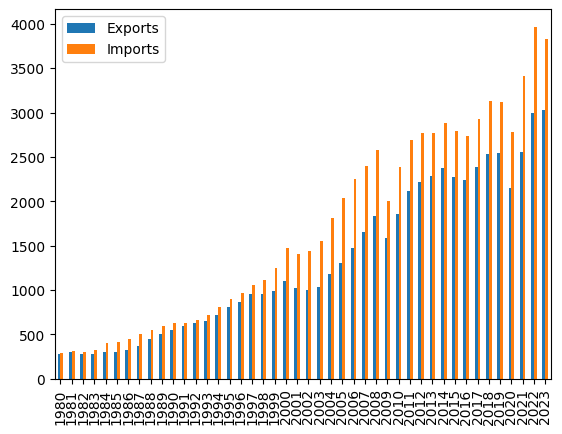

```python
xports = pd.DataFrame({'Exports':rawData.loc['Exports'], 'Imports':rawData.loc['Imports']})
print(rawData.loc['Exports'].mean())
print(rawData.loc['Imports'].mean())
xports.plot()
plt.show()

xports.plot(kind = 'bar')
plt.show()
```

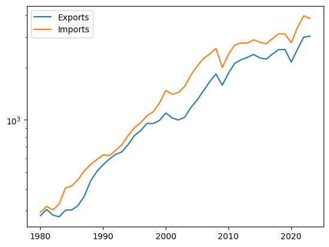

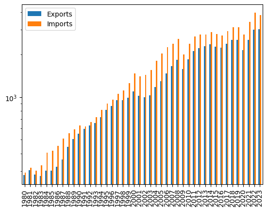

```python
xports = pd.DataFrame({'Exports':rawData.loc['Exports'], 'Imports':rawData.loc['Imports']})

xports.plot(logy = True)
plt.show()

xports.plot(kind = 'bar', logy = True)
plt.show()
```

By taking the log, we can see the difference more accurately as a line versus the exponential of the unadjusted function due to gross domestic product also being an exponential.

```
1980   -0.458475
1981   -0.389772
1982   -0.598122
1983   -1.419923
1984   -2.543590
          ...
2019   -2.688022
2020   -2.937673
2021   -3.637365
2022   -3.772126
2023   -2.919129
Name: Net Export/GDP, Length: 44, dtype: float64
-2.7049441737982196
```

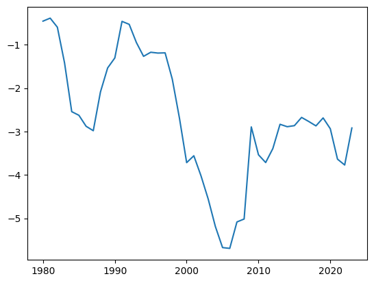

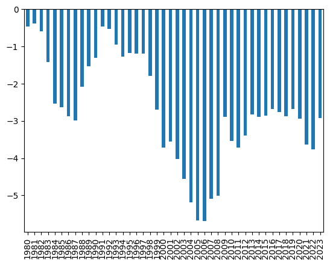

```python
rawData.loc['Net Export/GDP'] = rawData.loc['Net exports of goods and services']/rawData.loc['Gross domestic product']
rawData.loc['Net Export/GDP']*= 100
print(rawData.loc['Net Export/GDP'])

row = rawData.loc['Net Export/GDP']
print(row.mean())

row.plot()
plt.show()

row.plot(kind = 'bar')
plt.show()
```

Here we can actually see a negative effect on our gross domestic product which is much different from the past fields we looked at. Throughout the whole tested range, net exports has actually been more harmful to the national gross domestic product than helpful.

### 5) How much labor do we offshore versus send out? (how much work do we offshore versus how much does the rest of the world offshore from us?)

```
406.5022727272728
294.19545454545454
```

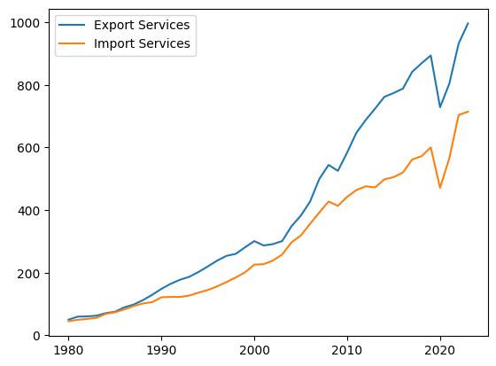

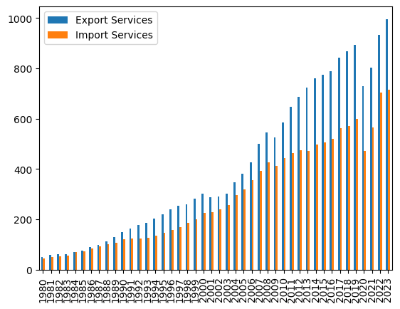

```python
xports = pd.DataFrame({'Export Services':rawData.loc['Services2'], 'Import Services':rawData.loc['Services3']})
print(rawData.loc['Services2'].mean())
print(rawData.loc['Services3'].mean())
xports.plot()
plt.show()

xports.plot(kind = 'bar')
plt.show()
```

Surprisingly, even with the new interest in offshoring many modern technology to developing countries, the USA exports a lot more services than it brings in. This could be due to the relative richness of the country compared to other countries alongside the incredible stability of the US economy (evident from the popularity of the US dollar in most country's government vaults).

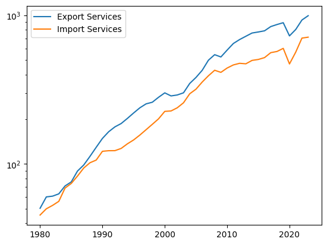

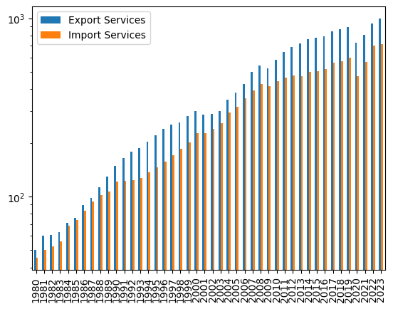

```python
xports = pd.DataFrame({'Export Services':rawData.loc['Services2'], 'Import Services':rawData.loc['Services3']})

xports.plot(logy = True)
plt.show()

xports.plot(kind = 'bar', logy = True)
plt.show()
```

Again, by taking the log we can erase the natural exponential growth rate to more accurately see the differences between the imports and exports. From it we can still see that there is a very clear difference between the export of USA services versus how many services the USA hires from other countries.

### 6) How much of gross domestic product is made up of our government's spending?

```
1980    20.634865
1981    20.405363
1982    21.278186
1983    21.095212
1984    20.504755
          ...
2019    17.609914
2020    18.734700
2021    17.771891
2022    17.273084
2023    17.342631
Name: Gov Spending/GDP, Length: 44, dtype: float64
19.304982360363038
```

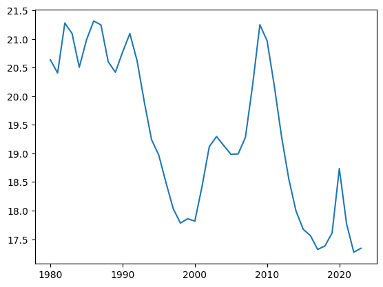

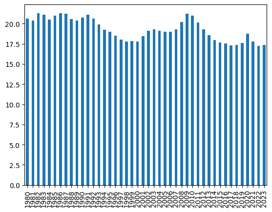

```python
rawData.loc['Gov Spending/GDP'] = rawData.loc['Government consumption expenditures and gross investment']/rawData.loc['Gross domestic product']
rawData.loc['Gov Spending/GDP']*= 100
print(rawData.loc['Gov Spending/GDP'])

row = rawData.loc['Gov Spending/GDP']
print(row.mean())

row.plot()
plt.show()

row.plot(kind = 'bar')
plt.show()
```

When looking at the visualization, we can draw a simple conclusion that the government tends to spend a pretty consistent amount of the gross domestic product every year. Even with the increasing budget deficit of the USA, the amount we spend out of the GDP tends to hover around 19.3%.

```
1980    31.105834
1981    32.610024
1982    34.490513
1983    35.494391
1984    36.091315
          ...
2019    22.457057
2020    22.143787
2021    21.430445
2022    20.877935
2023    20.962677
Name: Defense/Gov Spending, Length: 44, dtype: float64
26.792024812069613
```

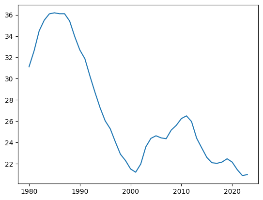

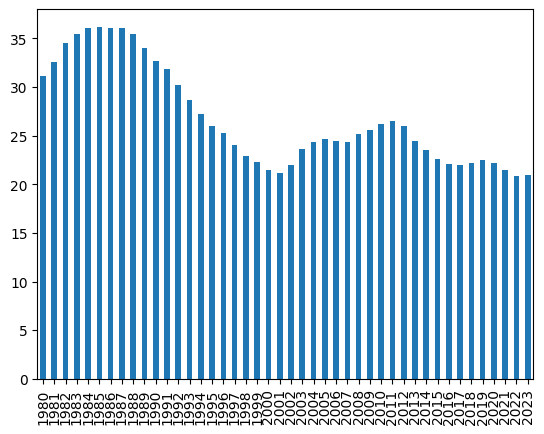

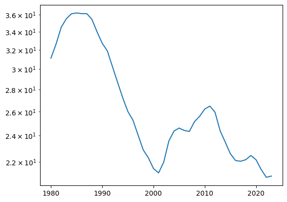

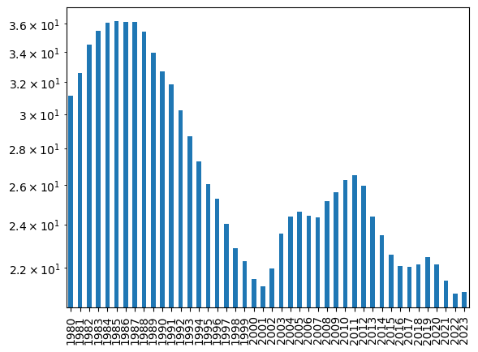

```python
rawData.loc['Defense/Gov Spending'] = rawData.loc['National defense']/rawData.loc['Government consumption expenditures and gross investment']
rawData.loc['Defense/Gov Spending']*= 100
print(rawData.loc['Defense/Gov Spending'])

row = rawData.loc['Defense/Gov Spending']
print(row.mean())

row.plot()
plt.show()

row.plot(kind = 'bar')
plt.show()

row.plot(logy = True)
plt.show()

row.plot(kind = 'bar', logy = True)
plt.show()
```

Please look at this data and compare it to your current knowledge of the USA economy. If anything surprised you try to think about and understand why. These graphs are created for the convenience of laymen who usually never approach this data due to its daunting size and I hope that these graphs and insights make it easier for you to understand the greater economic system of gross domestic product. Thank you for reading.